# Adult Weight Change Model

Rodrigo Zepeda Tello & Dalia Camacho García Formentí

2017-06-22

# The model

The Adult Weight Change Model estimates weight change for adult individuals from the paper in [https://www.ncbi.nlm.nih.gov/pmc/articles/PMC3880593/].

# Usage in R

The main inputs for the body weight change model are:

| Input | Meaning | Optional | Default |
| --- | --- | --- | --- |
| `bw` | Body Weight (kg) | No | - |
| `ht` | Height (m) | No | - |
| `age` | Age (yrs) | No | - |
| `sex` | Either `'male'` or `'female'` | No | - |

As an example consider a `40` year old `'female'` weighting `80` kg with `1.8` metres as height:

```r
female_model1 <- adult_weight(bw = 80, ht = 1.8, age = 40, sex = "female")
```

Furthermore, the model allows the user to input daily energy intake and sodium intake difference from baseline (for example, if doiing a `-100` kcal diet which reduces `-100` kcals from previous consumption)

| Input | Meaning | Optional | Default |
| --- | --- | --- | --- |
| `EIchange` | Energy intake difference from baseline (kcal) | Yes | No energy change |
| `NAchange` | Sodium intake difference from baseline (kcal) | Yes | No sodium change |

Note that this `-100` kcals is not cummulative. For example, if an individual consumes daily `2000` kcals a `EIchange = -100` means that in day 1 the individual consumes `1900` kcals; in day 2 the individual consumes `1900` kcals; in day 3 the individual consumes `1900` kcals, etc.

For example, our female can reduce her energy consumption by `-250` kcals and her sodium intake by `20` mg:

```r
female_model2 <- adult_weight(bw = 80, ht = 1.8, age = 40, sex = "female",
                      EIchange = rep(-250, 365), NAchange = rep(-20, 365))
```

If no `NAchange` is inputed, the model assumes a `0` change:

```r
female_model3 <- adult_weight(bw = 80, ht = 1.8, age = 40, sex = "female",
                      EIchange = rep(-250, 365))
```

The same is true for `EIchange`.

Note that in the examples above, `EIchange = rep(-250, 365)` is inputed as a vector with each day representing the consumption reduction for that day. See Energy Reduction section for additional information

Other (optional) inputs include:

| Input | Meaning | Optional | Default |
| --- | --- | --- | --- |
| `EI` | Energy intake (kcal) at baseline | Yes | Model estimate |
| `fat` | Fat mass (kg) of the individual | Yes | Model estimate |
| `PAL` | Physical activity level | Yes | $1.5$ |
| `pcarb_base` | % of baseline intake that is carbohydrates | Yes | $0.5$ |
| `pcarb` | % of intake after day $0$ that is carbohydrates | Yes | `pcarb_base` |

Hence the same female can consume `2000` kcals at baseline, with `22`kg of fat mass, having a physical activity level of `1.7` with a proportion of `0.6` kcals attributed to carbohydrates at baseline and `0.5` kcals attributed to carbohydrates after diet change.

```r
female_model4 <- adult_weight(bw = 80, ht = 1.8, age = 40, sex = "female",
                      EIchange = rep(-250, 365), EI = 2000, fat = 22,
                      PAL = 1.7, pcarb_base = 0.6, pcarb = 0.5)
```

Additional inputs include `days` to specify the model’s time span and `checkValues` which checks that the model’s results are biologically plausible (for example, that modelled body weight is always positive). All inputs used in the model are:

| Input | Meaning | Optional | Default |
| --- | --- | --- | --- |
| `bw` | Body Weight (kg) | No | - |
| `ht` | Height (m) | No | - |
| `age` | Age (yrs) | No | - |
| `sex` | Either `'male'` or `'female'` | No | - |
| `EIchange` | Energy intake difference from baseline (kcal) | Yes | No energy change |
| `NAchange` | Sodium intake difference from baseline (kcal) | Yes | No sodium change |
| `EI` | Energy intake (kcal) at baseline | Yes | Model estimate |
| `fat` | Fat mass (kg) of the individual | Yes | Model estimate |
| `PAL` | Physical activity level | Yes | $1.5$ |
| `pcarb_base` | % of baseline intake that is carbohydrates | Yes | $0.5$ |
| `pcarb` | % of intake after day $0$ that is carbohydrates | Yes | `pcarb_base` |
| `days` | Time period (days) to run the model | Yes | $365$ |
| `checkValues` | Check for internal consistency | Yes | `TRUE` |

Finally, we remark that one can also input data from a database to estimate individual-level weight change:

```r
#Database information
weights <- c(45, 67, 58, 92, 81)
heights <- c(1.30, 1.73, 1.77, 1.92, 1.73)
ages    <- c(45, 23, 66, 44, 23)
sexes   <- c("male", "female", "female", "male", "male")

#Returns a weight change matrix and other matrices
database_model <- adult_weight(weights, heights, ages, sexes)
```

## Plots

Result plots can be obtained by `model_plot` function:

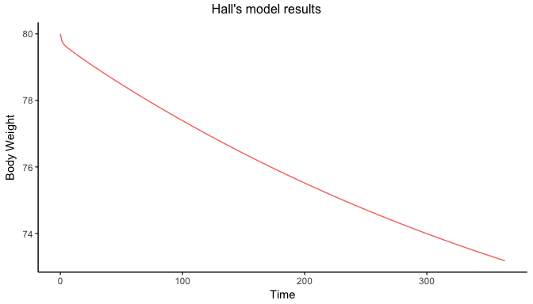

```r
model_plot(female_model2, "Body_Weight")
```

Plotting options include `"Body_Weight"`, `Fat_Mass`, `Lean_Mass`, `Glycogen`, `Extracellular_Fluid` and `Adaptive_Thermogenesis`. Several can be chosen at the same time:

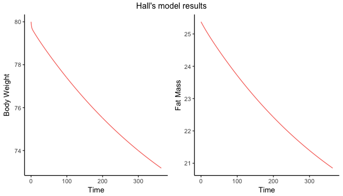

```r
model_plot(female_model2, c("Body_Weight", "Fat_Mass"))
```

Variables can also be plotted against age:

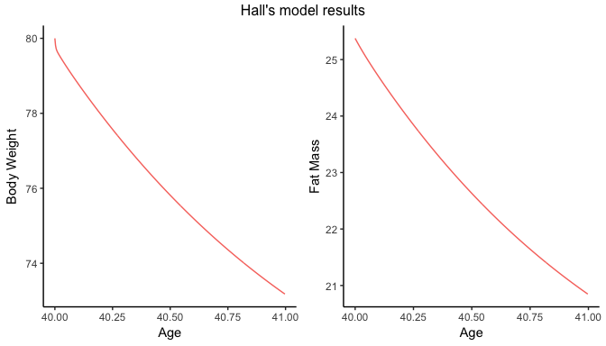

```r
model_plot(female_model2, c("Body_Weight", "Fat_Mass"), timevar = "Age")
```

## Energy Reduction

Energy intake change is usually not continuously measured but measured at different and distant points in time (say 1 year apart). The function `energy_build` allows the user to interpolate different energy models between the interpolation points. As an example consider an individual that by day `365` had reduced his consumption in `250` kcals and by day `730` had increased his consumption by `100` kcals (both compared to the consumption initially). The `energy_build` function interpolates those values via a Brownian Bridge:

```r
EIbrownian <- energy_build(c(0, -250, 100), c(0, 365, 730))
```

The interpolation looks like this:

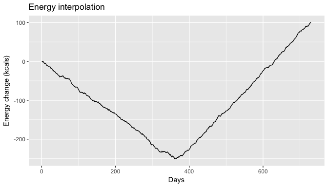

```r
ggplot() + geom_line(aes(x = 1:730, y = EI), data = data.frame(EI = EIbrownian)) +
  xlab("Days") + ylab("Energy change (kcals)") + ggtitle("Energy interpolation")
```

Such energy change matrix can be directly inputed in the model:

```r
model_brownian <- adult_weight(70, 1.75, 22, "male", EIbrownian, days = 730)
```

Other interpolation modes include `Linear`, `Exponential`, `Stepwise_R` (right stepwise), `Stepwise_L` (left stepwise), and `Logarithmic`:

```r
EIlinear      <- energy_build(c(0, -250, 100), c(0, 365, 730), "Linear")
EIexponential <- energy_build(c(0, -250, 100), c(0, 365, 730), "Exponential")
EIstepwise_r  <- energy_build(c(0, -250, 100), c(0, 365, 730), "Stepwise_R")
EIstepwise_l  <- energy_build(c(0, -250, 100), c(0, 365, 730), "Stepwise_L")
EIlogarithmic <- energy_build(c(0, -250, 100), c(0, 365, 730), "Logarithmic")
```

Which look like this:

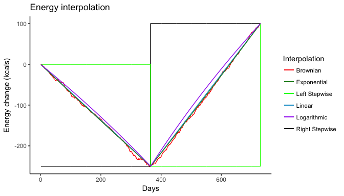

```r
ggplot() +
  geom_line(aes(x = 1:730, y = EI, color = "Brownian"), data = data.frame(EI = EIbrownian)) +
  geom_line(aes(x = 1:730, y = EI, color = "Linear"), data = data.frame(EI = EIlinear)) +
  geom_line(aes(x = 1:730, y = EI, color = "Exponential"), data = data.frame(EI = EIexponential)) +
  geom_step(aes(x = 1:730, y = EI, color = "Right Stepwise"), data = data.frame(EI = EIstepwise_r)) +
  geom_step(aes(x = 1:730, y = EI, color = "Left Stepwise"), data = data.frame(EI = EIstepwise_l)) +
  geom_line(aes(x = 1:730, y = EI, color = "Logarithmic"), data = data.frame(EI = EIlogarithmic)) +
  xlab("Days") + ylab("Energy change (kcals)") + ggtitle("Energy interpolation") +
  theme_classic() +
  scale_color_manual("Interpolation",
                     values = c("Brownian" = "red", "Linear" = "deepskyblue3",
                                "Exponential" = "forestgreen", "Logarithmic" = "purple",
                                "Right Stepwise" = "black", "Left Stepwise" = "green"))
```

These models result in different weight changes:

```r
model_linear      <- adult_weight(70, 1.75, 22, "male", EIlinear, days = 730)
model_exponential <- adult_weight(70, 1.75, 22, "male", EIexponential, days = 730)
model_logarithmic <- adult_weight(70, 1.75, 22, "male", EIlogarithmic, days = 730)
model_stepwise_r  <- adult_weight(70, 1.75, 22, "male", EIstepwise_r, days = 730)
model_stepwise_l  <- adult_weight(70, 1.75, 22, "male", EIstepwise_l, days = 730)
```

Which look as follows:

[figure not shown]

```r
ggplot() +
  geom_line(aes(x = 1:730, y = as.vector(model_linear[["Body_Weight"]]), color = "Linear")) +
  geom_line(aes(x = 1:730, y = as.vector(model_exponential[["Body_Weight"]]), color = "Exponential")) +
  geom_line(aes(x = 1:730, y = as.vector(model_logarithmic[["Body_Weight"]]), color = "Logarithmic")) +
  geom_line(aes(x = 1:730, y = as.vector(model_stepwise_r[["Body_Weight"]]), color = "Right Stepwise")) +
  geom_line(aes(x = 1:730, y = as.vector(model_stepwise_l[["Body_Weight"]]), color = "Left Stepwise")) +
  geom_line(aes(x = 1:730, y = as.vector(model_brownian[["Body_Weight"]]), color = "Brownian")) +
  xlab("Days") + ylab("Weight (kg)") +
  ggtitle("Weight change under different energy interpolations") +
    scale_color_manual("Interpolation",
                     values = c("Brownian" = "red", "Linear" = "deepskyblue3",
                                "Exponential" = "forestgreen", "Logarithmic" = "purple",
                                "Right Stepwise" = "black", "Left Stepwise" = "green"))
```

## Estimating mean weight change